# Lab2.4

Ema Richnakova

2024-03-31

```r
suppressMessages(library(tidyverse))
suppressMessages(library(magrittr))
```

# Sampling

## Simple sampling

### Task 1

Load the dataset and explore it. How data look like? Is it necessary to perform any adjustment to make the linear regression model?

- data are linear, no adjustmnets are needed

```r
#setwd("cv/cv6/")
inc <- read_csv("income.data.csv", col_names = TRUE, num_threads = 4)
```

```
## ──────────────────────────────────────────────────────── Delimiter: "," dbl
## (3): ...1, income, happiness
```

```r
head(inc)
```

```
## # A tibble: 6 × 3
##    ...1 income happiness
##   <dbl>  <dbl>     <dbl>
## 1     1   3.86      2.31
## 2     2   4.98      3.43
## 3     3   4.92      4.60
## 4     4   3.21      2.79
## 5     5   7.20      5.60
## 6     6   3.73      2.46
```

```r
sample <- sample(c(TRUE, FALSE), nrow(inc), replace=TRUE, prob=c(0.7,0.3))
train <- inc[sample, ]
test <- inc[!sample, ]

model_lm <- lm(formula=happiness ~ ., data=train)
summary(model_lm)
```

```
##
## Call:
## lm(formula = happiness ~ ., data = train)
##
## Residuals:
##      Min       1Q   Median       3Q      Max
## -2.00498 -0.50591  0.02935  0.45399  2.40412
##
## Coefficients:
##              Estimate Std. Error t value Pr(>|t|)
## (Intercept) 0.1602368  0.1252373   1.279    0.202
## ...1        0.0002683  0.0002690   0.997    0.319
## income      0.7126870  0.0224893  31.690   <2e-16 ***
## ---
## Signif. codes:  0 '***' 0.001 '**' 0.01 '*' 0.05 '.' 0.1 ' ' 1
##
## Residual standard error: 0.7279 on 356 degrees of freedom
## Multiple R-squared:  0.739,  Adjusted R-squared:  0.7375
## F-statistic:   504 on 2 and 356 DF,  p-value: < 2.2e-16
```

### Task 2

Perform the modelling and compare the RMSE for training and testing dataset. What is the outcome?

```r
suppressMessages(library(caret)) # confusion matrix + RMSE

R2model <- sum(model_lm$residuals^2)
RMSEmodel <- sqrt(R2model / length(model_lm$residuals))
paste("The RMSE for training dataset is: ", RMSEmodel)
```

```
## [1] "The RMSE for training dataset is:  0.724896207375894"
```

```r
predicted_test<-predict(model_lm,test)
RMSE_test <- RMSE(predicted_test, test$happiness)
print(paste("The RMSE for testing dataset is:", RMSE_test))
```

```
## [1] "The RMSE for testing dataset is: 0.697364048152677"
```

## K-fold cross-validation

**Simple K-Folds** — We split our data into K parts. We split it into ten parts, part 1 to part 10. We then build 10 different models, each model is trained on 9 parts and tested on the remaining.

### Task 3

Create 10 folds using function createFolds() from the caret library. On each fold, perform linear regression and compare the RMSE results. What does it tell about your model and your data?

```r
# Create indices for 10-fold cross-validation
folds <- createFolds(y = 1:nrow(inc), k = 10, list = TRUE, returnTrain = FALSE)
perform_linear_regression <- function(data, folds) {
  results <- list()
  for (i in 1:length(folds)) {
    # Get the indices for the current fold
    fold_indices <- unlist(folds[-i])
    # Split the data into training and testing sets
    train_data <- data[fold_indices, ]
    test_data <- data[folds[[i]], ]
    # Fit the linear regression model
    lm_model <- lm(happiness ~ ., data = train_data)
    # Predict on the test data
    predicted <- predict(lm_model, newdata = test_data)
    # Calculate RMSE
    rmse <- sqrt(mean((test_data$happiness - predicted)^2))
    # Store the results
    results[[i]] <- list(
      lm_model = lm_model,
      predicted = predicted,
      actual = test_data$happiness,
      rmse = rmse
    )
  }
  return(results)
}
# Call the function with your data and folds
results <- perform_linear_regression(inc, folds)
# Print RMSE for each fold
for (i in 1:length(results)) {
    cat("Fold", i, "RMSE:", results[[i]]$rmse, "\n")
}
```

```
## Fold 1 RMSE: 0.6003285
## Fold 2 RMSE: 0.7563205
## Fold 3 RMSE: 0.8648754
## Fold 4 RMSE: 0.7984743
## Fold 5 RMSE: 0.6542641
## Fold 6 RMSE: 0.6982687
## Fold 7 RMSE: 0.7548511
## Fold 8 RMSE: 0.6200034
## Fold 9 RMSE: 0.7698994
## Fold 10 RMSE: 0.6398872
```

**Why is the cross-validation important?**  
helps us better use our data, and it gives us much more information about our algorithm performance. In complex machine learning models, it’s sometimes easy not pay enough attention and use the same data in different steps of the pipeline. This may lead to good but not real performance in most cases, or, introduce strange side effects in others. We have to pay attention that we’re confident in our models. Cross-Validation helps us when we’re dealing with non-trivial challenges in our Data Science projects.

# ROC curves

**linear discriminant anakysis (LDA)**

- prepare data for LDA
- apply LDA onto dataset a visualize the outcome
- learn how to estimate the best cut-odd for classification methods automatically by researching receiver operating characteristics, ROC.

LDA shines when there is substantial separation (aka clear water) between 2 classes, because parameter estimates for the logistic regression model become unstable.

```r
library(MASS) # LDA library
```

### Task 1

Load the credit dataset Default.csv (you will find it on the server). Think about the dataset. Does balance values fulfills all requirement for LDA? Which test would you chose to compare the distributions of balance values between defaulters and non-defaulters? How would you modify the data to be ready for using in your LDA model?

- one-hot encoding is needed for Yes/No

```r
data <- read_csv("Default.csv", col_names = TRUE, num_threads = 4)
head(data)
```

```
## # A tibble: 6 × 4
##   default student balance income
##   <chr>   <chr>     <dbl>  <dbl>
## 1 No      No         730. 44362.
## 2 No      Yes        817. 12106.
## 3 No      No        1074. 31767.
## 4 No      No         529. 35704.
## 5 No      No         786. 38463.
## 6 No      Yes        920.  7492.
```

One-hot encoding (**we can not use Yes/No**)

```r
# default
data$default <- ifelse(data$default == "Yes", 1, 0)
# student
data$student <- ifelse(data$student == "Yes", 1, 0)
# Converting to binary variables to factors
data %<>% mutate(default = as_factor(default))
data %<>% mutate(student = as_factor(student))
data
```

```
## # A tibble: 10,000 × 4
##    default student balance income
##    <fct>   <fct>     <dbl>  <dbl>
##  1 0       0          730. 44362.
##  2 0       1          817. 12106.
##  3 0       0         1074. 31767.
##  4 0       0          529. 35704.
##  5 0       0          786. 38463.
##  6 0       1          920.  7492.
##  7 0       0          826. 24905.
##  8 0       1          809. 17600.
##  9 0       0         1161. 37469.
## 10 0       0            0  29275.
## # ℹ 9,990 more rows
```

### Task 2

Analyze the data you want to classify? How does the defaulters and the non-defaulters groups look like? What inferences do you draw from your analysis?

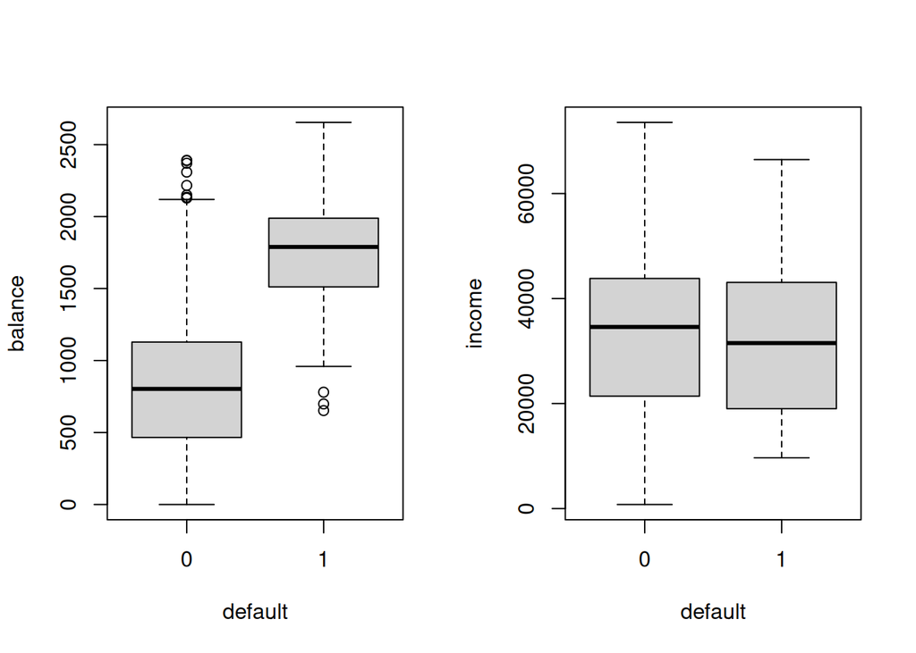

```r
par(mfrow=c(1,2))
boxplot(balance ~ default, data = data)
boxplot(income ~ default, data = data)
```

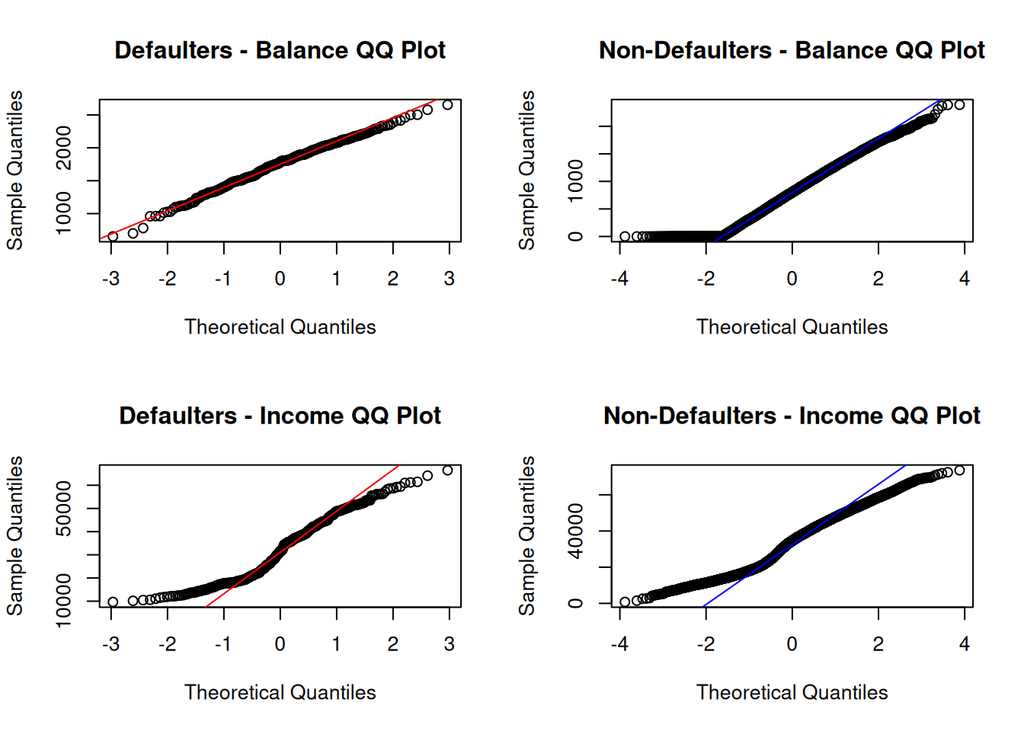

```r
par(mfrow=c(1,1))

par(mfrow=c(2,2))
# QQ plot for "balance" variable by default status
qqnorm(data$balance[data$default == 1], main = "Defaulters - Balance QQ Plot")
qqline(data$balance[data$default == 1], col = "red")
qqnorm(data$balance[data$default == 0], main = "Non-Defaulters - Balance QQ Plot")
qqline(data$balance[data$default == 0], col = "blue")
# QQ plot for "income" variable by default status
qqnorm(data$income[data$default == 1], main = "Defaulters - Income QQ Plot")
qqline(data$income[data$default == 1], col = "red")
qqnorm(data$income[data$default == 0], main = "Non-Defaulters - Income QQ Plot")
qqline(data$income[data$default == 0], col = "blue")
```

```r
par(mfrow=c(1,1))  # Reset plotting parameters
```

```r
model_lda <- lda(default ~ balance, data = data)
lda_predict <- predict(object = model_lda)
```

### Task 4

Analyze the structure of the prediction object. What does it tell you?

- this

```r
model_lda
```

```
## Call:
## lda(default ~ balance, data = data)
##
## Prior probabilities of groups:
##      0      1
## 0.9667 0.0333
##
## Group means:
##     balance
## 0  803.9438
## 1 1747.8217
##
## Coefficients of linear discriminants:
##                 LD1
## balance 0.002206916
```

```r
str(lda_predict)
```

```
## List of 3
##  $ class    : Factor w/ 2 levels "0","1": 1 1 1 1 1 1 1 1 1 1 ...
##  $ posterior: num [1:10000, 1:2] 0.997 0.996 0.987 0.999 0.996 ...
##   ..- attr(*, "dimnames")=List of 2
##   .. ..$ : chr [1:10000] "1" "2" "3" "4" ...
##   .. ..$ : chr [1:2] "0" "1"
##  $ x        : num [1:10000, 1] -0.2336 -0.0402 0.5256 -0.6756 -0.1097 ...
##   ..- attr(*, "dimnames")=List of 2
##   .. ..$ : chr [1:10000] "1" "2" "3" "4" ...
##   .. ..$ : chr "LD1"
```

```r
head(lda_predict$class)
```

```
## [1] 0 0 0 0 0 0
## Levels: 0 1
```

```r
head(lda_predict$posterior) # Extract sigma hat values for each class
```

```
##           0           1
## 1 0.9972130 0.002786981
## 2 0.9958358 0.004164240
## 3 0.9865931 0.013406929
## 4 0.9988882 0.001111757
## 5 0.9963955 0.003604464
## 6 0.9933487 0.006651334
```

## Receiver operating characteristics

Default cut-off for logistic regression might not be best cut-off possible  
comparing 0.5 cut-off to LDA doesn’t make sense. Find ideal cut-off with ROC (Receiver Operating Characteristics).  
ROC curve represents the optimal trade-off between True Positive Rate (TRP) and False Positive Rate (FPR).

#### Cut-off

Threshold used to classify observations into different groups or classes based on their predicted discriminant scores.

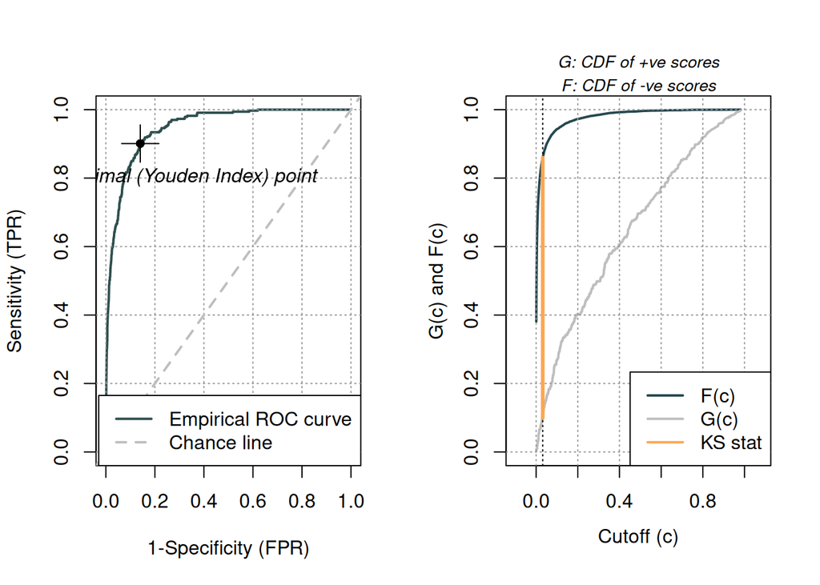

```r
library(ROCit) # ROC curves library
model_glm <- glm(default ~ balance, data = data, family = binomial)

roc <- rocit(class = model_glm$y,
             score = model_glm$fitted.values)

par(mfrow = c(1,2))
plot(roc)
ksplot(roc)
```

```r
par(mfrow = c(1,1))
summary(roc)
```

```
##
##  Method used: empirical
##  Number of positive(s): 333
##  Number of negative(s): 9667
##  Area under curve: 0.948
```

**AUC (Area Under Curve)**

- higher better
- classification-threshold-invariant
- best way how to tell which classification method is better (comparing ROC of logistic regression and LDA)

even better library than ROCit for data mining is **pROC**

## pROC

best for data mining

```r
library(pROC) # ROC calculation
pROC <- pROC::roc(data$default, data$balance, algorithm = 2)
pROC_results <- coords(pROC, "local maximas", ret=c("threshold", "sens", "spec",
                                          "ppv", "npv", "youden", "closest.topleft"))
head(pROC_results)
```

```
##   threshold sensitivity specificity        ppv       npv   youden
## 1  652.3849    1.000000   0.3807800 0.05269821 1.0000000 1.380780
## 2  698.5398    0.996997   0.4153305 0.05548128 0.9997510 1.412328
## 3  779.9149    0.993994   0.4818455 0.06198502 0.9995708 1.475839
## 4  959.1111    0.990991   0.6266680 0.08377761 0.9995050 1.617659
## 5  961.4805    0.987988   0.6284266 0.08390717 0.9993420 1.616415
## 6  961.6541    0.984985   0.6285301 0.08369482 0.9991778 1.613515
##   closest.topleft
## 1       0.3834334
## 2       0.3418474
## 3       0.2685202
## 4       0.1394579
## 5       0.1382111
## 6       0.1382154
```

```r
tail(pROC_results)
```

```
##     threshold sensitivity specificity       ppv       npv   youden
## 214  2134.475  0.11411411   0.9993793 0.8636364 0.9703696 1.113493
## 215  2152.313  0.10210210   0.9994828 0.8717949 0.9699829 1.101585
## 216  2218.648  0.06606607   0.9995862 0.8461538 0.9688189 1.065652
## 217  2315.388  0.03903904   0.9996897 0.8125000 0.9679487 1.038729
## 218  2378.889  0.02402402   0.9997931 0.8000000 0.9674675 1.023817
## 219  2402.164  0.02102102   1.0000000 1.0000000 0.9673772 1.021021
##     closest.topleft
## 214       0.7847942
## 215       0.8062209
## 216       0.8722328
## 217       0.9234461
## 218       0.9525291
## 219       0.9583998
```

### Task 5

Investigate data frame that you got from pROC. Why are there only 219 rows?

```r
max_youden <- max(pROC_results$youden) ; max_youden
```

```
## [1] 1.760526
```

## cutpointr

easiest way to get cutoff point  
gives you the exact optimal cutpoint along with the multitude of other measurements

```r
suppressMessages(library(cutpointr)) # optimal cutoff point
cp <- cutpointr(data, balance, default, method = maximize_metric, metric = sum_sens_spec)
```

```
## Assuming the positive class is 1
```

```
## Assuming the positive class has higher x values
```

```r
summary(cp)
```

```
## Method: maximize_metric
## Predictor: balance
## Outcome: default
## Direction: >=
##
##    AUC     n n_pos n_neg
##  0.948 10000   333  9667
##
##  optimal_cutpoint sum_sens_spec   acc sensitivity specificity  tp fn   fp   tn
##          1315.559        1.7605 0.861      0.9009      0.8596 300 33 1357 8310
##
## Predictor summary:
##     Data     Min.           5%   1st Qu.    Median      Mean  3rd Qu.      95%
##  Overall   0.0000    0.4246597  481.7311  823.6370  835.3749 1166.308 1665.963
##        0   0.0000    0.0000000  465.7146  802.8571  803.9438 1128.249 1569.803
##        1 652.3971 1140.2272417 1511.6110 1789.0934 1747.8217 1988.870 2265.088
##      Max.       SD NAs
##  2654.323 483.7150   0
##  2391.008 456.4762   0
##  2654.323 341.2668   0
```

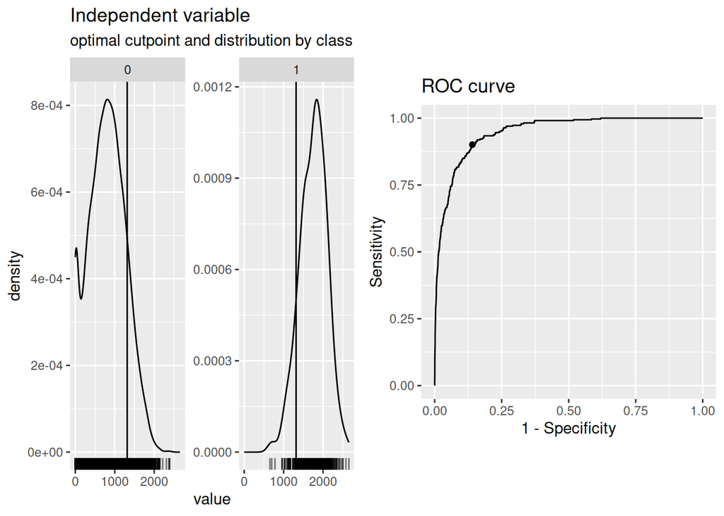

```r
plot(cp)
```

### Task 7

Think about the optimal cutoff point. What does it tell you? Is the optimal cutoff always optimal? How does it go with your goals?